# An Introduction to SuperLearner, a loss-based ensemble prediction algorithm

April 14, 2016

## Overview

1. Background on the development of super learner and targeted learning
2. Theory behind the super learner algorithm
3. Application of super learner in R
4. Some (hopefully) helpful comments on utilizing super learner

This presentation, the data (with documentation) and R code is available at: https://github.com/sfgrey/Super-Learner-Presentation.git

## Background

## Background

"Essentially, all models are wrong, but some are useful"  
- George Box, 1979

Mantra of statisticians regarding the development of statistical models for many years

In the 1990s an awareness developed among statisticians (Breiman, Harrell) that this approach was wrong

- Parametric model assumptions rarely met
- Large number of variables makes it difficult to correctly specify a model

Simultaneously, computer scientists and some statisticians developed the machine learning field to address the limitations of parametric models

## Targeted learning

Combines advanced machine learning with efficient semiparametric estimation to provide a framework for answering causal questions from data

- Developed by Mark van der Laan research group at UC Berkeley
- Started with the seminal 2006 article on targeted maximum likelihood estimation

Central motivation is the belief that statisticians treat estimation as *Art* not **Science**

- This results in misspecified models that are data-adaptively selected, but this part of the estimation procedure is not accounted for in the variance

## Estimation is a Science, *Not an Art*

### Specific definitions required

1. **Data**: realizations of random variables with a probability distribution
2. **Model**: actual knowledge about the data generating probability distribution
3. **Target Parameter**: a feature of the data generating probability distribution
4. **Estimator**: an a priori-specified algorithm, benchmarked by a dissimilarity-measure (e.g., MSE) w.r.t. target parameter

## Theory

## Data

Random variable \(O\), observed \(n\) times, defined in a simple case as $O=( A,W,Y )∼ P 0$ if we are without common issues such as missingness and censoring

- \(A\): exposure or treatment
- \(W\): vector of covariates
- \(Y\): outcome
- $P 0$: the true probability distribution

This data structure makes for an effective example, but data structures found in practice are much more complicated

## Model

General case: Observe \(n\) i.i.d. copies of random variable \(O\) with probability distribution $P 0$

The data-generating distribution $P 0$ is also known to be an element of a statistical model $M: P 0 ∈M$

A **statistical** model \(M\) is the set of possible probability distributions for $P 0$; it is a collection of probability distributions

If all we know is that we have \(n\) i.i.d. copies of \(O\), this can be our statistical model, which we call a non-parametric statistical model

## Target Parameters

Define the parameter of the probability distribution \(P\) as function of $P:Ψ( P )$

In a causal inference (specificly the Neyman-Rubin) framework, a target parameter for the effect of \(A\) would be
$$Ψ( P 0 )= E W,0 [ E 0 ( Y|A=1,W )− E 0 ( Y|A=0,W ) ]$$

Note that this requires additional, nontestable assumptions to infer causality

- $( A⊥ Y a |W )$ ; SUTVA; Positivity
- Does not change the statistical model \(M\)

## Estimators

The target parameter $Ψ( P 0 )$ depends on $P 0$ through the conditional mean $Q ¯ 0 ( A,W )= E 0 ( Y|A,W )$ and the marginal distribution $Q W,0$ of \(W\); or

$$Q ¯ ( A,W )=E( Y|A,W )/ Q ¯ ( W )=E( Y|W )$$

Where $Q ¯$ is an **estimator** of $Q ¯ 0 ( A,W )$, shortened to $Q ¯ 0$

An **estimator** is an algorithm that can be applied to any empirical distribution to provide a mapping from the empirical distribution to the parameter space

- But which algorithm?

## Effect Estimation vs. Prediction

Both **effect** and **prediction** research questions are inherently *estimation* questions, but they are distinct in their goals

- **Prediction**: Interested in generating a function to input covariates and predict a value for the outcome: $E 0 ( Y|W )$
- **Effect**: Interested in estimating the true effect of exposure on outcome adjusted for covariates, $Ψ( P 0 )$, the **targeted estimand**
- Targeted maximum likelihood estimation (TMLE), is an iterative procedure that updates an initial (super learner) estimate of the relevant part $Q ¯ 0$ of the data generating distribution $P 0$
- See second presentation given on April 12 to the Ann Arbor ASA Chapter

## Prediction: Key Concepts

1. **Loss-based estimation**: Use **loss functions** to define best estimator of $E 0 ( Y|W )$ & evaluate it
2. **Flexible Estimation**: Allow **data** to drive your **estimates**, but in an honest (cross validated) way
3. **Cross Validation**: Available data is partitioned to **train** and **validate** our estimators

These are detailed topics; we'll cover core concepts

## Loss-Based Estimation

In order to choose a "best" algorithm to estimate $Q ¯ 0$, must have a way to define what "best" means

Given the data structure is $O=( W,Y )∼ P 0$, with empirical distribution $P n$ which places probability \(1/n\) on each observed $O i$, \(i=1,...,n\)

A loss function, $L( O, Q ¯ )$, assigns a measure of performance to a candidate function $Q ¯$ when applied to an observation \(O\)

One of the most commonly used loss functions is the \(L2\) squared error (or quadratic) loss function:

$$L( O, Q ¯ )= ( Y− Q ¯ ( W ) ) 2$$

## The Parameter of Interest

We define our parameter of interest, $Q ¯ 0 = E 0 ( Y|W )$ , as the minimizer of the expected squared error loss:

$$Q ¯ 0 =arg min Q ¯ E 0 L( O, Q ¯ )$$

$E 0 L( O, Q ¯ )$, which we want to be small, evaluates the candidate $Q ¯$, and it is minimized at the optimal choice of $Q ¯ 0$

We refer to expected loss as the **risk**

We want estimator that minimizes the expectation of the squared error loss function; we want an estimator that has small bias and variance

## Flexible Estimation

The Super Learner algorithm finds the combination of algorithms minimizing the cross-validated risk

For a given problem, a "library" of candidate prediction algorithms can be proposed

- *Recommend* using a diverse set of learners (Linear Model, Support Vector Machine, Random Forest, Neural Net, etc.)
- Multi-step algorithm involving screening covariates and optimizing tuning parameters
- As long as the algorithm takes the observed \(W\) and outputs a predicted \(Y\)

No need to decide beforehand which algorithm to use; can use several by incorporating **cross-validation**

## Cross-Validation

Consider a candidate library of \(C\) prediction algorithms ${ Q ¯ 1 ,…, Q ¯ C }$

In V-fold cross-validation, the observed data $O i$, \(i=1,...,n\), is referred to as the learning set and is partitioned into \(V\) sets of size $≈n/V$

For any given fold, \(V-1\) sets comprise a training set and remaining 1 set is a validation set

For each candidate algorithm in \(C\), V-fold cross-validation is used to generate \(n\) cross-validated predicted values associated with the \(C^{th}\) learner, the results are stored in a $n×C$ matrix, \(Z\)

## Super Learner: Ensembling

Super Learner is a "generalized stacking" ensemble learning technique

- A second-level learner, or a *metalearner*
- It is trained with \(Z\), the cross-validated predicted values from each candidate algorithm
- Used as inputs in a working statistical model to predict the original \(Y\)
- Use the least squares algorithm to solve for $( α 1 ,…, α C )$, the weight vector that minimizes
  $$∑ i=1 n ( Y i − ∑ c=1 C α c z ci ) 2$$

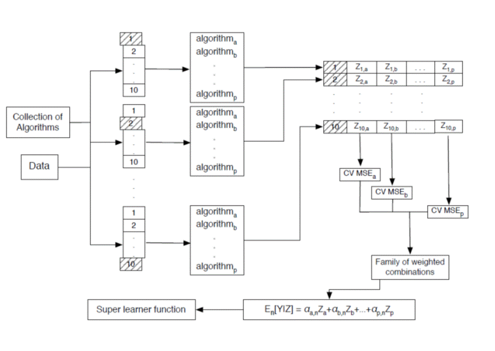

## Super Learner: Ensembling

Super Learner is an *oracle selector*, defined as the estimator, among all possible weighted combinations of the \(C\) prediction functions, that minimizes risk under the true data-generating distribution

- Thus, by adding more competitors, we only improve the performance of the super learner
- The asymptotic equivalence remains true if the number of algorithms in the library grows very quickly with sample size

## Application of super learner

## The SuperLearner R Package

### Created by Eric Polley, National Cancer Institute

Table: Main functions in the SuperLearner package

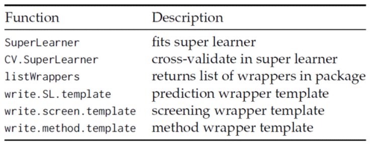

## CV SuperLearner

```r
pm1 <- CV.SuperLearner(Y=Y,
                       x=x,
                       V=10,
                       family=binomial(),
                       SL.library=SL.library,
                       method="method.NNLS",
                       verbose = TRUE,
                       control = list(saveFitLibrary = TRUE),
                       cvControl = list(V=10), saveAll = TRUE,
                       parallel = 'multicore')
```

## SuperLearner Arguments

**Required:**

- `Y` - The outcome
- `X` - The covariates
- `V` - The number of folds for the metalearner
- `family` - 'gaussian' or 'binomial' to describe the error distribution
- `SL.library` - a character vector or a list of prediction algorithms
- `method` - Method used by metalearner to combine the individual algorithms. The default is non-negative least squares

## SuperLearner Arguments

**Optional:**

- `verbose` - helpful to set this to `TRUE` to see the progress of the estimation
- `control` - Parameters to control the estimation process, like saving the fit for each algorithm
- `cvControl` - controls the cross-validation process of the individual prediction algorithms, i.e. the number of splits for the V-fold cross-validation
- `parallel` - Options for parallel computation of the V-fold step

  Can be platform specfic!

## Canidate algorithms in SuperLearner

There are two types of candidate algorithms that can be used in `SL.library`:

1. **Prediction algorithms**: Algorithms that take as input `X` and `Y` and return a predicted \(Y\) value
2. **Screening algorithms**: Algorithms designed to reduce the dimension of \(X\). They take as input `X` and `Y` and return a logical vector indicating the columns in `X` passing the screening

Screening algorithms can be coupled with prediction algorithms to form new prediction algorithms

## Canidate algorithms in SuperLearner

There are two ways to specify the algorithms in `SL.library`:

1. A character vector:  
   `c("SL.glm", "SL.glmnet"", "SL.gam")`
2. A list of character vectors:  
   `list(c("SL.glm", "screen.corP"), "SL.gam")`

If only using prediction algorithms, easier to use the first method. If using screening algorithms, the list is required

- Prediction algorithm listed first, followed by the screening algorithms
- Multiple screening algorithms can be used

## Prediction algorithm wrappers in SuperLearner

```r
listWrappers(what = "SL")
```

```
## All prediction algorithm wrappers in SuperLearner:
```

```
##  [1] "SL.bayesglm"         "SL.caret"            "SL.caret.rpart"
##  [4] "SL.cforest"          "SL.earth"            "SL.gam"
##  [7] "SL.gbm"              "SL.glm"              "SL.glm.interaction"
## [10] "SL.glmnet"           "SL.ipredbagg"        "SL.knn"
## [13] "SL.leekasso"         "SL.loess"            "SL.logreg"
## [16] "SL.mean"             "SL.nnet"             "SL.nnls"
## [19] "SL.polymars"         "SL.randomForest"     "SL.ridge"
## [22] "SL.rpart"            "SL.rpartPrune"       "SL.step"
## [25] "SL.step.forward"     "SL.step.interaction" "SL.stepAIC"
## [28] "SL.svm"              "SL.template"
```

## Screening algorithm wrappers in SuperLearner

```r
listWrappers(what = "screen")
```

```
## All screening algorithm wrappers in SuperLearner:
```

```
## [1] "All"
## [1] "screen.corP"           "screen.corRank"        "screen.glmnet"
## [4] "screen.randomForest"   "screen.SIS"            "screen.template"
## [7] "screen.ttest"          "write.screen.template"
```

## Examining a wrapper function

```r
SL.glmnet
```

```
## function (Y, X, newX, family, obsWeights, id, alpha = 1, nfolds = 10,
##     nlambda = 100, useMin = TRUE, ...)
## {
##     .SL.require("glmnet")
##     if (!is.matrix(X)) {
##         X <- model.matrix(~-1 + ., X)
##         newX <- model.matrix(~-1 + ., newX)
##     }
##     fitCV <- glmnet::cv.glmnet(x = X, y = Y, weights = obsWeights,
##         lambda = NULL, type.measure = "deviance", nfolds = nfolds,
##         family = family$family, alpha = alpha, nlambda = nlambda)
##     pred <- predict(fitCV$glmnet.fit, newx = newX, s = ifelse(useMin,
##         fitCV$lambda.min, fitCV$lambda.1se), type = "response")
##     fit <- list(object = fitCV, useMin = useMin)
##     class(fit) <- "SL.glmnet"
##     out <- list(pred = pred, fit = fit)
##     return(out)
## }
## <environment: namespace:SuperLearner>
```

## Creating your own wrappers

Many algorithms are included in the package, but you may want to create your own

A few reasons to build your own wrappers:

- Want to use an algorithm not currently included
- Want to include a range of tuning parameters, not just the default
- Force variables to be used in chunk-wise fashion

## Example

### Creating your own wrapper to alter a tuning parameter

`glmnet` algorithm evaluates elastic net (penalized regression) models

The `alpha` tuning parameter controls the amount of shrinkage to estimated coefficients the algorithm applies, 1=LASSO, 0=Ridge

As `SL.ridge` wrapper doesn’t handle binary variables, need to modify the wrapper to utilize various penalized regression models

```r
SL.glmnet.0 <- function(..., alpha = 0){
  SL.glmnet(..., alpha = alpha)
  } # ridge penalty
```

## Important notes for creating prediction wrappers

- Input must following naming syntax: Y, X, …
- Name of new function must be different than one already in the package
- Must return a list with 2 elements named `pred` and `fit`
- `pred` must be a vector with the predicted \(Y\) values
- `fit` can be anything if not using `predict` method, otherwise is a list with elements needed for `predict`

## SuperLearner example

### Predicting 30 day mortality for patients admitted to an ICU

The ARF dataset has 2490 observations and 47 variables including:

- **Demographic characteristics**, including age, gender, weight and race
- **Patient medical history**, 12 dichotomous variables for medicial conditions: MI, COPD, stroke, cancer, etc.
- **Current condition variables**, that provide information about the patient's current health status: three diagnostic scales, vital statistics and current disease status

Can we build a good prediction model of 30 day mortality?

## Preparing data for SuperLearner

Only works with numeric matrices; can be specified in-line, i.e. `Y= dataset$Y`

Data must be preprocessed:

[figure not shown]